# Божин Кацарски - Домашно по R №2

фн 81291, Компютърни науки, 3 курс, 1 поток

### 1 зад.

```r
install.packages("UsingR")
```

```
Error in install.packages : Updating loaded packages
```

```r
library("UsingR")
data(homedata)
homes = homedata[(91 * 50) : (91 * 50 + 49), ]
homes
```

|  | y1970 | y2000 |
| --- | --- | --- |
| 4550 | 71000 | 297600 |
| 4551 | 95900 | 401900 |
| 4552 | 56700 | 237600 |
| 4553 | 92500 | 387600 |
| 4554 | 93600 | 392200 |
| 4555 | 83000 | 347700 |
| 4556 | 86200 | 361100 |
| 4557 | 75100 | 314600 |
| 4558 | 83000 | 347600 |
| 4559 | 124600 | 521700 |

[output cut: 40 more lines]

```r
t.test(homes["y1970"], conf.level = 0.97)
```

```
    One Sample t-test

data:  homes["y1970"]
t = 32.556, df = 49, p-value < 2.2e-16
alternative hypothesis: true mean is not equal to 0
97 percent confidence interval:
 76016.4 87223.6
sample estimates:
mean of x
    81620
```

```r
t.test(homes["y2000"], conf.level = 0.97)
```

```
    One Sample t-test

data:  homes["y2000"]
t = 32.525, df = 49, p-value < 2.2e-16
alternative hypothesis: true mean is not equal to 0
97 percent confidence interval:
 317773.2 364670.8
sample estimates:
mean of x
   341222
```

```r
t.test(homes["y1970"], y = homes["y2000"], conf.level = 0.97)
```

```
    Welch Two Sample t-test

data:  homes["y1970"] and homes["y2000"]
t = -24.067, df = 54.578, p-value < 2.2e-16
alternative hypothesis: true difference in means is not equal to 0
97 percent confidence interval:
 -283637.6 -235566.4
sample estimates:
mean of x mean of y
    81620    341222
```

Получихме 97% доверителен интервал [76 016.40, 87 223.60] за цените през 1970г и [317 773.20, 364 670.80] за цените през 2000г.

Чрез съвместен тест на Стюдънт с ниво на довериe 97% получаваме p-value 2.2е-16, което е много малко. Следователно отхвърляме хипотезата, че цените са се запазили от 1970 до 2000.

### 2 зад.

```
Call:
lm(formula = y ~ x)

Coefficients:
(Intercept)            x
     139.31        21.57
```

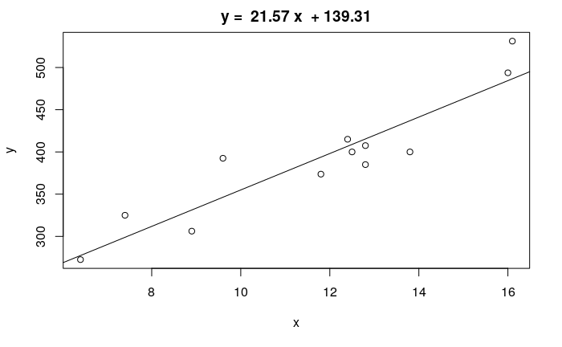

```r
rain = c(8.9, 6.4, 12.8, 9.6, 13.8, 16.1, 12.4, 12.8, 11.8, 16.0, 7.4, 12.5)
crops = c(306.2, 272.5, 385.0, 392.5, 400.0, 531.2, 415.0, 407.5, 373.7, 493.7, 325.0, 400.0)
simple.lm(rain, crops)
```

Когато начертаем линейния модел на зависимостта на реколтата от валежите със simple.lm, получаваме формулата y = 21.57 * x + 139.31. Следователно при валежи 5 + 1 = 6 cm/m2 можем да очакваме реколта 268.73 kg/декар.

```r
new_rain = 5 + 1
new_crop = 21.57 * new_rain + 139.31
new_crop
```

```
[1] 268.73
```

Формулата също така сочи, че при увеличаване на валежите с 1cm/m2, реколтата се увеличавас 21.57kg/dka (което е по-малко от 24).

### 3 зад.

```r
first = c(39, 50, 61, 67, 40, 40, 54)
second = c(60, 53, 42, 41, 40, 54, 63, 69)
t.test(x = first, y = second, alternative = "less")
```

```
    Welch Two Sample t-test

data:  first and second
t = -0.45541, df = 12.665, p-value = 0.3283
alternative hypothesis: true difference in means is less than 0
95 percent confidence interval:
     -Inf 7.551634
sample estimates:
mean of x mean of y
 50.14286  52.75000
```

Имаме хипотезата, че двата вида печки греят за еднкво време, като алтернтивата е, че първите греят по-бързо. Проверяваме хипотезата с тест на Стюдънт с ниво на доверие 95%. Получаваме p-value = 0.3283, което сравнително голямо. Това означава, че нямаме основание да отхрълим хипотезата, тоест не можем да приемем алтернативата.

### 4 зад.

```r
azbestos_cancer = data.frame(
    total_people = c(5000, 520),
    people_with_lung_cancer = c(48, 12)
)
azbestos_cancer # in the city and in offices with azbestos
```

| total_people | people_with_lung_cancer |
| --- | --- |
| 5000 | 48 |
| 520 | 12 |

```r
chisq.test(azbestos_cancer)
```

```
    Pearson's Chi-squared test with Yates' continuity correction

data:  azbestos_cancer
X-squared = 6.5249, df = 1, p-value = 0.01064
```

Извършваме хи квадрат тест на хипотезата, че рака на белите дробове е независим от азбеста в мазилката с помощта на функцията chisq.test. Получаваме p-value = 0.01064, което е доста малко, следователно имаме основание да отхвърлим хипотезата и да приемем алтернативата, че има връзка между азбеста в мазилката и рака на белите дробове.

### 5 зад.

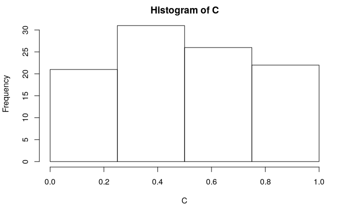

```r
A = rexp(100, rate=10)
B = rexp(100, rate=10)
C = A / (A + B)
hist(C, breaks=c(0.00, 0.25, 0.50, 0.75, 1.00))
```

```r
ks.test(C, "punif", 0, 1)
```

```
    One-sample Kolmogorov-Smirnov test

data:  C
D = 0.087585, p-value = 0.4269
alternative hypothesis: two-sided
```

При тестване на хипотезата, че данните C са равномерно разпределени в [0;1] с Колмогоров-Смирнов тест, полуихме голямо (>0.05) p-value, което означава, че не можем да отхвърлим хипотезата, че данните са равномерно разпределени.